# Project

# Doing KNN

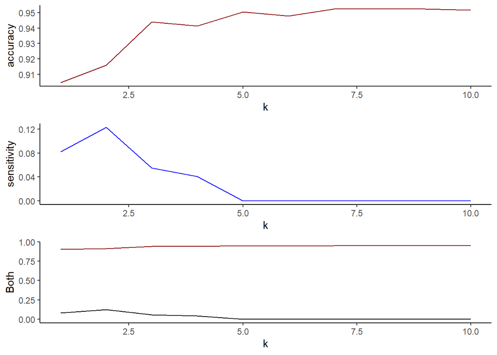

```r
### Creating the graph for best K. (column 21/22 = stroke0/stroke1)

set.seed(1)
nk = 10
metrics.knn <- data.frame(k = seq(1, nk, 1), accuracy = rep(0, nk), sensitivity = rep(0, nk), F1_score = rep(0, nk))

for(i in 1:nk) {
  knn.pred = knn(train.norm.knn[, -18], valid.norm.knn[, -18], cl = train.norm.knn[, 18], k = i)
  metrics.knn[i, 2] = confusionMatrix(knn.pred, valid.norm.knn[, 18], positive = "1")$overall[1]
  metrics.knn[i, 3] = confusionMatrix(knn.pred, valid.norm.knn[, 18], positive = "1")$byClass[1]
}

accuracy.plot = ggplot(data= metrics.knn) + geom_line(aes(x=k,y=accuracy), color="darkred") + theme_classic()
sensitivity.plot = ggplot(data= metrics.knn) + geom_line(aes(x=k,y=sensitivity), color="blue") + theme_classic()
both.plot = ggplot(data= metrics.knn) + geom_line(aes(x=k,y=accuracy), color="darkred") + geom_line(aes(x=k,y=sensitivity))+ ylab("Both") + theme_classic()

plot_grid(accuracy.plot, sensitivity.plot, both.plot, ncol = 1, align = "v")
```

```r
# Compute best trade-off sensitivity-accuracy
metrics.knn$difference = sqrt((metrics.knn$accuracy - metrics.knn$sensitivity)^2)
k.best = metrics.knn$k[which.min(metrics.knn$difference)]
k.best
```

```
## [1] 2
```

```r
### Creating the confusion Matrix --> need just to change the K = 1 & the 21 corresponds to the stroke variable.

pred.knn = knn(train.norm.knn[, -18], valid.norm.knn[, -18], cl = train.norm.knn[, 18], k = k.best, prob = T)
## k.best = 1:
conf.knn = confusionMatrix(pred.knn, valid.norm.knn[, 18], positive = "1")
conf.knn
```

```
## Confusion Matrix and Statistics
##
##           Reference
## Prediction    0    1
##          0 1384   61
##          1   76   12
##
##                Accuracy : 0.9106
##                  95% CI : (0.8952, 0.9244)
##     No Information Rate : 0.9524
##     P-Value [Acc > NIR] : 1.0000
##
##                   Kappa : 0.1023
##
##  Mcnemar's Test P-Value : 0.2317
##
##             Sensitivity : 0.164384
##             Specificity : 0.947945
##          Pos Pred Value : 0.136364
##          Neg Pred Value : 0.957785
##              Prevalence : 0.047619
##          Detection Rate : 0.007828
##    Detection Prevalence : 0.057404
##       Balanced Accuracy : 0.556164
##
##        'Positive' Class : 1
##
```

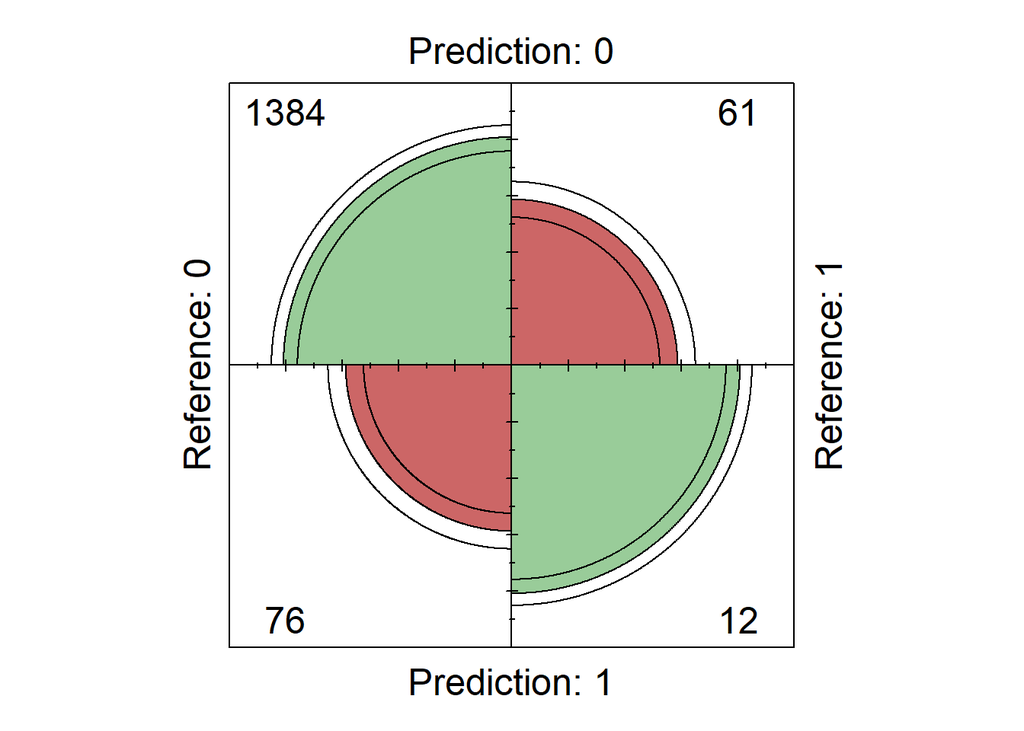

```r
fourfoldplot(confusionMatrix(pred.knn, valid.norm.knn[, 18], positive = "1")$table, color = c("#CC6666", "#99CC99"))
```

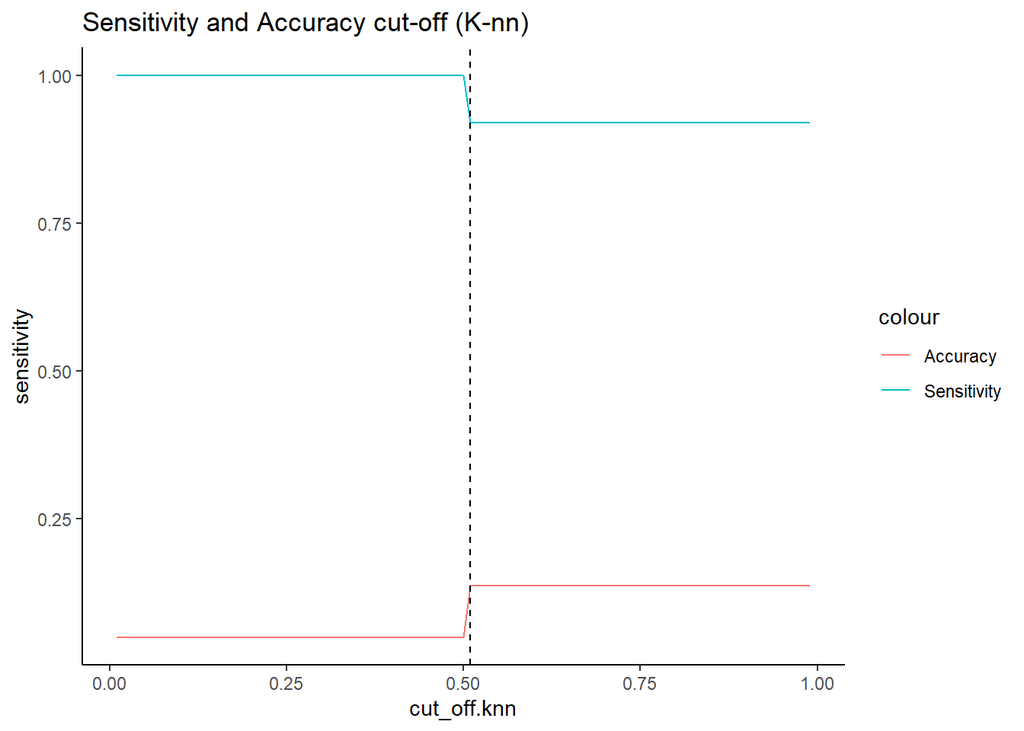

```r
pred.knn.prob = attr(pred.knn, "prob")

# KNN: Find the best cut-off:
cut_off.knn = seq(0.01,0.99,0.01)
metrics.knn.prob <- data.frame(cut_off.knn, sensitivity = rep(0, length(cut_off.knn)), accuracy = rep(0, length(cut_off.knn)))

for (i in 1:length(cut_off.knn)){
  x <- as.factor(ifelse(pred.knn.prob >= cut_off.knn[i],1,0))
  metrics.knn.prob[i, 2] <- confusionMatrix(x, valid.lr$stroke, positive = "1")$byClass[1]
  metrics.knn.prob[i, 3] <- confusionMatrix(x, valid.lr$stroke, positive = "1")$overall[1]
}

cutoff.plot.knn = ggplot(data= metrics.knn.prob) + geom_line(aes(x=cut_off.knn,y=sensitivity, color="Sensitivity")) + geom_line(aes(x=cut_off.knn,y=accuracy, color = "Accuracy")) + geom_vline(xintercept = 0.51 , linetype="dashed") + theme_classic() + ggtitle("Sensitivity and Accuracy cut-off (K-nn)")

cutoff.plot.knn
```

```r
metrics.knn.prob$difference = sqrt((metrics.knn.prob$accuracy - metrics.knn.prob$sensitivity)^2)
cut_off.knn.best = cut_off.knn[which.min(metrics.knn.prob$difference)]
cut_off.knn.best
```

```
## [1] 0.51
```

```r
# Confusion matrix (final)
conf.knn2 = confusionMatrix(as.factor(ifelse(pred.knn.prob > cut_off.knn.best, 1, 0)), valid.ct$stroke, positive = "1")
conf.knn2
```

```
## Confusion Matrix and Statistics
##
##           Reference
## Prediction    0    1
##          0  139    6
##          1 1319   69
##
##                Accuracy : 0.1357
##                  95% CI : (0.1189, 0.1538)
##     No Information Rate : 0.9511
##     P-Value [Acc > NIR] : 1
##
##                   Kappa : 0.0016
##
##  Mcnemar's Test P-Value : <0.0000000000000002
##
##             Sensitivity : 0.92000
##             Specificity : 0.09534
##          Pos Pred Value : 0.04971
##          Neg Pred Value : 0.95862
##              Prevalence : 0.04892
##          Detection Rate : 0.04501
##    Detection Prevalence : 0.90541
##       Balanced Accuracy : 0.50767
##
##        'Positive' Class : 1
##
```

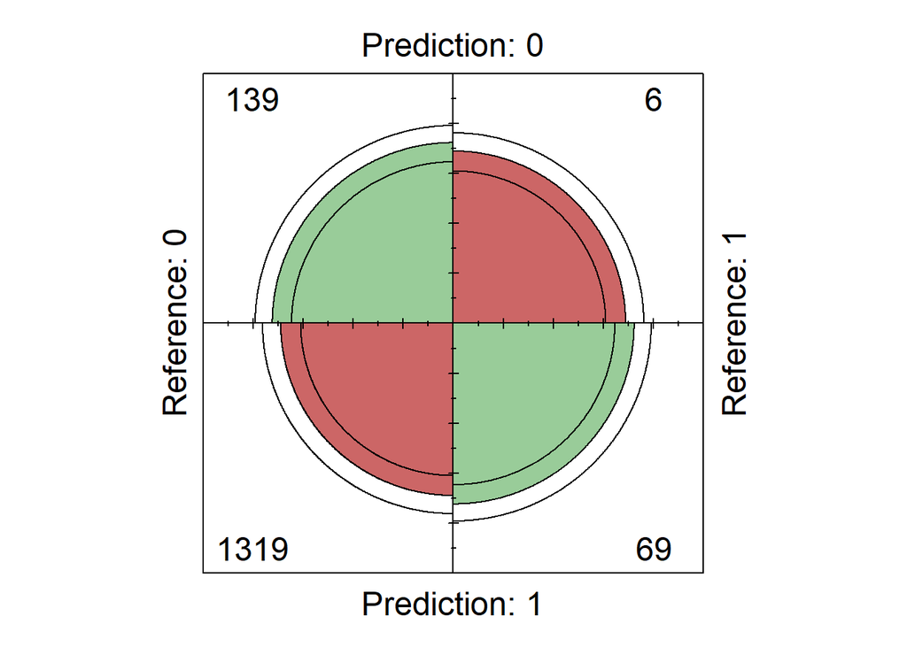

```r
fourfoldplot(confusionMatrix(as.factor(ifelse(pred.knn.prob > cut_off.knn.best, 1, 0)), valid.ct$stroke, positive = "1")$table, color = c("#CC6666", "#99CC99"))
```

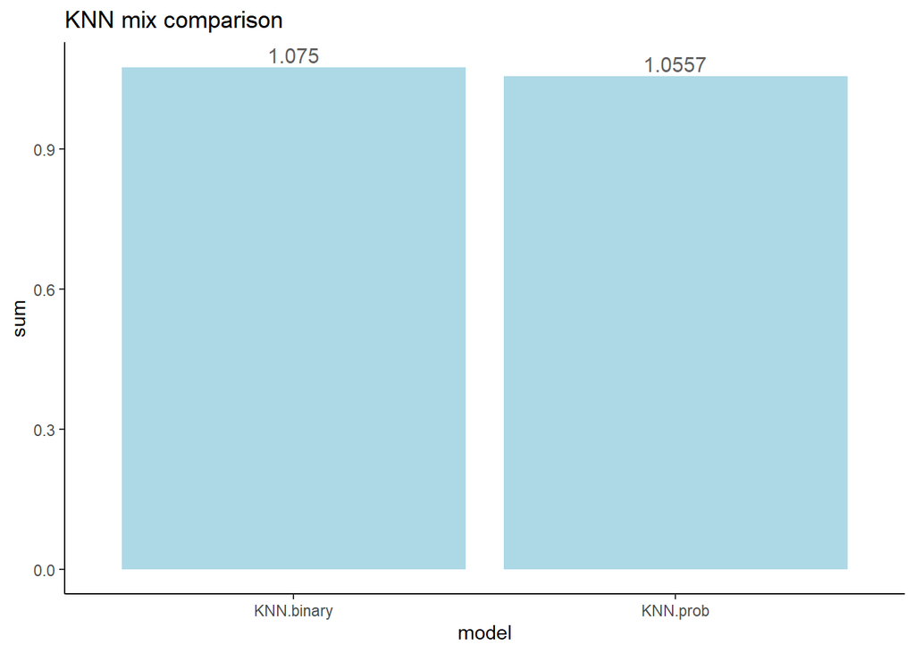

```r
# KNN Comparison
knn.type = c("KNN.binary", "KNN.prob")
acc.knn = c(conf.knn$overall[1], conf.knn2$overall[1])
sens.knn = c(conf.knn$byClass[1], conf.knn2$byClass[1])
knn.both.df = data.frame(knn.type, "accuracy" = acc.knn, "sensitivity" = sens.knn)

knn.both.df$sum = knn.both.df$accuracy + knn.both.df$sensitivity

ggplot(aes(x=knn.type, y=sum), data = knn.both.df) + geom_col(fill = "lightblue") + ylab("sum") + xlab("model") + ggtitle("KNN mix comparison") + geom_text(aes(label = round(sum,4)), colour = "grey38", size = 4, vjust = -0.3) + theme_classic()
```

```r
# Keep the best mix:
conf.knn = conf.knn2
```

#### 4) Ensemble methods

```r
#pred.ct.prob = predict(best.pruned, valid.ct, type = "prob", parms = list(prior= c(ratio_0, ratio_1)))[,2]

#pred.knn.prob = attr(pred.knn, "prob")

# LR:
results.df = data.frame(actual = valid.lr$stroke, lr.binary = as.factor(ifelse(pred.lr > cut_off.best, 1, 0)), lr.prob = pred.lr, ct.binary = pred.ct, ct.prob = pred.ct.prob, knn.binary = pred.knn, knn.prob = pred.knn.prob)

for(i in 1:NROW(results.df)){
  fix_prob = if(results.df[i,"knn.binary"]==1) results.df[i,"knn.prob"] else 1 - results.df[i,"knn.prob"]
  results.df[i,"knn.prob"] = fix_prob
}

accuracy.df = data.frame("LR.Accuracy" = conf.lr$overall[1], "CT.Accuracy" = conf.ct$overall[1], "KNN.Accuracy" = conf.knn$overall[1])

sensitivity.df = data.frame("LR.Sensitivity" = conf.lr$byClass[1], "CT.Sensitivity" = conf.ct$byClass[1], "KNN.Sensitivity" = conf.knn$byClass[1])
```

```r
# Ensembles:
results.df$average.prob = apply(results.df[,c(3,5,7)],FUN = mean, MARGIN = 1)
results.df[,c(2,4,6)] = sapply(results.df[,c(2,4,6)], as.integer) - 1
results.df$major.voting = as.factor(apply(results.df[,c(2,4,6)],FUN = function(x)
names(table(melt(x)$value))[which.max(table(melt(x)$value))], MARGIN = 1))

# Majority vote (ensemble):
accuracy.df = cbind(accuracy.df, ensemble = confusionMatrix(results.df$major.voting, results.df$actual, positive = "1")$overall[1])
sensitivity.df = cbind(sensitivity.df, ensemble = confusionMatrix(results.df$major.voting, results.df$actual, positive = "1")$byClass[1])
```

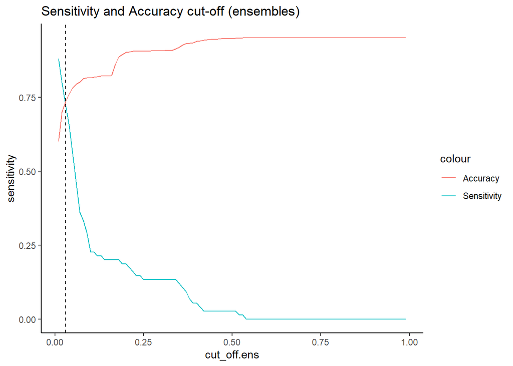

```r
# Average (ensemble):
# Find the cutoff for average (ensemble): that maximizes both sensitivity and overall accuracy

# Find the best ensemble cut-off:
cut_off.ens = seq(0.01,0.99,0.01)
metrics.ens <- data.frame(cut_off.ens, sensitivity = rep(0, length(cut_off.ens)), accuracy = rep(0, length(cut_off.ens)))

for (i in 1:length(cut_off.ens)){
  x <- as.factor(ifelse(results.df$average.prob >= cut_off.ens[i],1,0))
  metrics.ens[i, 2] <- confusionMatrix(x, results.df$actual, positive = "1")$byClass[1]
  metrics.ens[i, 3] <- confusionMatrix(x, results.df$actual, positive = "1")$overall[1]
}

cutoff.plot.ens = ggplot(data= metrics.ens) + geom_line(aes(x=cut_off.ens,y=sensitivity, color="Sensitivity")) + geom_line(aes(x=cut_off.ens,y=accuracy, color = "Accuracy")) + geom_vline(xintercept = 0.03 , linetype="dashed") + theme_classic() + ggtitle("Sensitivity and Accuracy cut-off (ensembles)")

cutoff.plot.ens
```

```r
metrics.ens$difference = sqrt((metrics.ens$accuracy - metrics.ens$sensitivity)^2)
cut_off.best.ens = cut_off.ens[which.min(metrics.ens$difference)]
cut_off.best.ens
```

```
## [1] 0.03
```

```r
accuracy.df = cbind(accuracy.df, ensemble.prob = confusionMatrix(as.factor(ifelse(results.df$average.prob > cut_off.best.ens, 1, 0)), results.df$actual, positive = "1")$overall[1])
sensitivity.df = cbind(sensitivity.df, ensemble.prob = confusionMatrix(as.factor(ifelse(results.df$average.prob > cut_off.best.ens, 1, 0)), results.df$actual, positive = "1")$byClass[1])

head(results.df)
```

```
##      actual lr.binary     lr.prob ct.binary ct.prob knn.binary knn.prob
## 4119      0         0 0.011839232         0       0          0        0
## 1380      0         0 0.011537197         0       0          0        0
## 1050      0         0 0.005209831         0       0          0        0
## 1708      0         0 0.004610370         0       0          0        0
## 1087      0         0 0.027484257         0       0          0        0
## 2566      0         0 0.037786301         0       0          0        0
##      average.prob major.voting
## 4119  0.003946411            0
## 1380  0.003845732            0
## 1050  0.001736610            0
## 1708  0.001536790            0
## 1087  0.009161419            0
## 2566  0.012595434            0
```

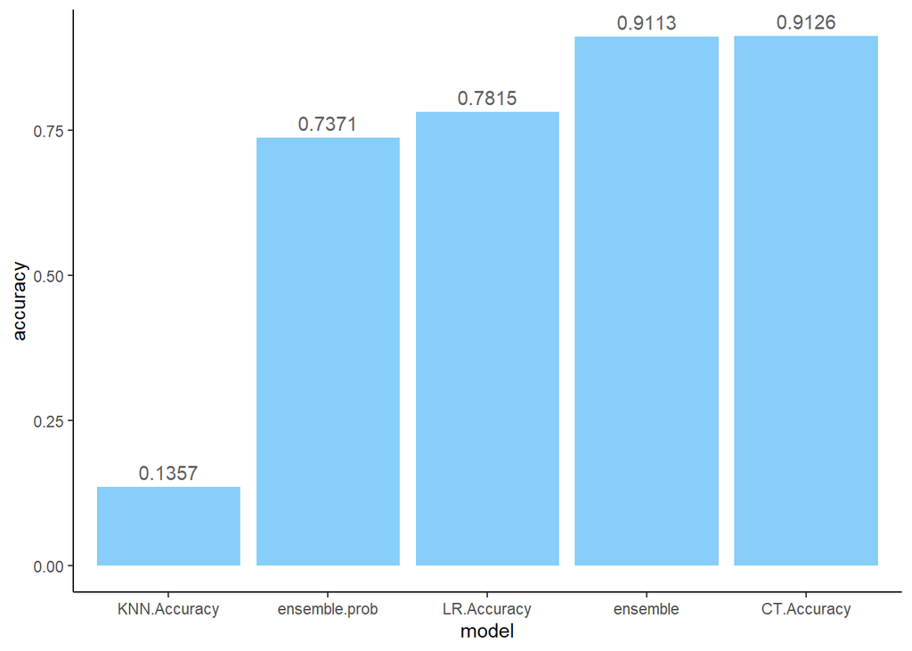

```r
accuracy.df.melt = melt(accuracy.df)
accuracy.plot = ggplot(aes(x=reorder(variable, value), y=value), data = accuracy.df.melt) + geom_col(fill="lightskyblue") + ylab("accuracy") + xlab("model") +
geom_text(aes(label = round(value, 4)), vjust = -0.5, colour = "grey38") + theme_classic()
accuracy.plot
```

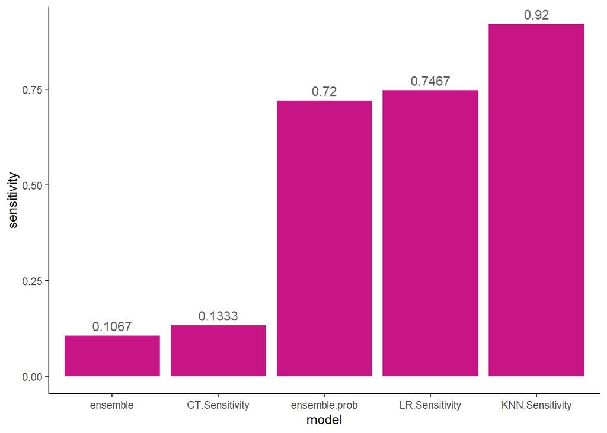

```r
sensitivity.df.melt = melt(sensitivity.df)
sensitivity.plot = ggplot(aes(x=reorder(variable, value), y=value), data = sensitivity.df.melt) + geom_col(fill="mediumvioletred") + ylab("sensitivity") + xlab("model") +
geom_text(aes(label = round(value, 4)), vjust = -0.5, colour = "grey38") + theme_classic()
sensitivity.plot
```

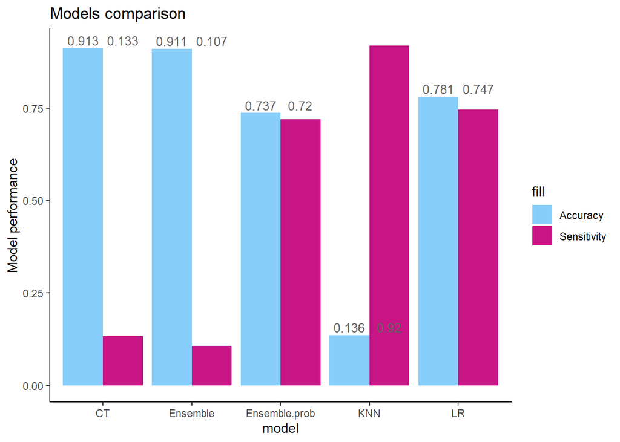

```r
both.melt = accuracy.df.melt
both.melt[,1] = c("LR", "CT", "KNN", "Ensemble", "Ensemble.prob")
both.melt[,3] <- sensitivity.df.melt$value
colnames(both.melt) <- c("method", "accuracy", "sensitivity")

both.melt.plot = ggplot(both.melt, aes(x = method, y= accuracy)) + geom_col(aes(fill = "Accuracy"), width = 0.45, position = position_nudge(x = -0.225)) + geom_text(aes(label = round(accuracy,3)), colour = "grey38", size = 3.5, vjust = -0.3, position = position_nudge(x = -0.225))+
  geom_col(aes(y = sensitivity, fill = "Sensitivity"), width = 0.45, position = position_nudge(x = 0.225)) + geom_text(aes(label = round(sensitivity,3)), colour = "grey38", size = 3.5, vjust = -0.3, position = position_nudge(x = 0.225))+
  ylab("Model performance") + xlab("model") + ggtitle("Models comparison") + scale_fill_manual(values = c("lightskyblue", "mediumvioletred")) + theme_classic()
both.melt.plot
```

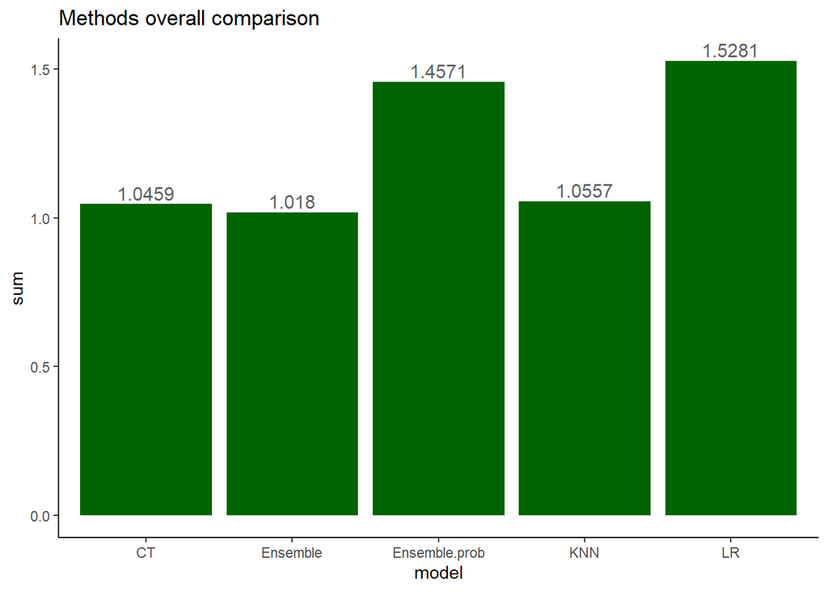

```r
acc = c(accuracy.df[1,1], accuracy.df[1,2], accuracy.df[1,3], accuracy.df[1,4], accuracy.df[1,5])
sens = c(sensitivity.df[1,1], sensitivity.df[1,2], sensitivity.df[1,3], sensitivity.df[1,4], sensitivity.df[1,5])
method = c("LR", "CT", "KNN", "Ensemble", "Ensemble.prob")
both.df = data.frame(method, "accuracy"= acc, "sensitivity"=sens)

both.df$sum = both.df$accuracy + both.df$sensitivity

#barplot(sum ~ method, both.df, main = "Methods overall comparison", ylab = "accuracy + sensitivity", xlab = "", las = 2)

both.plot = ggplot(aes(x=method, y=sum), data = both.df) + geom_col(fill = "darkgreen") + ylab("sum") + xlab("model") + ggtitle("Methods overall comparison") + geom_text(aes(label = round(sum,4)), colour = "grey38", size = 4, vjust = -0.3) + theme_classic()
both.plot
```

#### 5) Best model: Prediction

LR is the best fitted model => use this method as the basis for prediction.

```r
set.seed(1)
# Reduced GLM
logit.reg2 <- glm(stroke ~ age + hypertension + heart_disease + avg_glucose_level , data = train.lr, family = "binomial")
options(scipen = 999)
summary(logit.reg2)
```

```
##
## Call:
## glm(formula = stroke ~ age + hypertension + heart_disease + avg_glucose_level,
##     family = "binomial", data = train.lr)
##
## Deviance Residuals:
##     Min       1Q   Median       3Q      Max
## -1.2155  -0.3263  -0.1693  -0.0782   3.7872
##
## Coefficients:
##                    Estimate Std. Error z value             Pr(>|z|)
## (Intercept)       -7.475759   0.512806 -14.578 < 0.0000000000000002 ***
## age                0.069560   0.007352   9.462 < 0.0000000000000002 ***
## hypertension       0.656781   0.218815   3.002              0.00269 **
## heart_disease      0.604553   0.245133   2.466              0.01365 *
## avg_glucose_level  0.003033   0.001654   1.834              0.06663 .
## ---
## Signif. codes:  0 '***' 0.001 '**' 0.01 '*' 0.05 '.' 0.1 ' ' 1
##
## (Dispersion parameter for binomial family taken to be 1)
##
##     Null deviance: 1033.36  on 2553  degrees of freedom
## Residual deviance:  809.96  on 2549  degrees of freedom
## AIC: 819.96
##
## Number of Fisher Scoring iterations: 7
```

```r
pred.lr2 = predict(logit.reg2, valid.lr[,-10], type = "response")
# Confusion matrix with best cut-off (0.4):
conf.lr2 = confusionMatrix(as.factor(ifelse(pred.lr2 > cut_off.best, 1, 0)), valid.lr$stroke, positive = "1")
conf.lr2
```

```
## Confusion Matrix and Statistics
##
##           Reference
## Prediction    0    1
##          0 1134   17
##          1  324   58
##
##                Accuracy : 0.7776
##                  95% CI : (0.7559, 0.7982)
##     No Information Rate : 0.9511
##     P-Value [Acc > NIR] : 1
##
##                   Kappa : 0.1874
##
##  Mcnemar's Test P-Value : <0.0000000000000002
##
##             Sensitivity : 0.77333
##             Specificity : 0.77778
##          Pos Pred Value : 0.15183
##          Neg Pred Value : 0.98523
##              Prevalence : 0.04892
##          Detection Rate : 0.03783
##    Detection Prevalence : 0.24918
##       Balanced Accuracy : 0.77556
##
##        'Positive' Class : 1
##
```

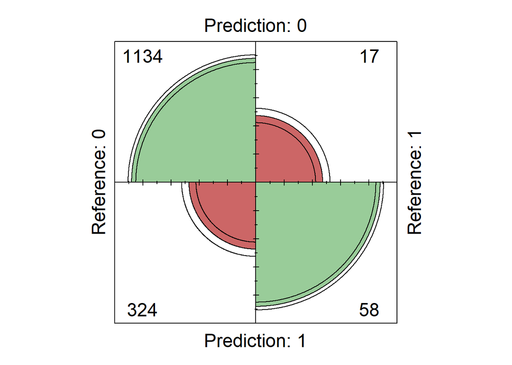

```r
fourfoldplot(confusionMatrix(as.factor(ifelse(pred.lr2 > cut_off.best, 1, 0)), valid.lr$stroke, positive = "1")$table, color = c("#CC6666", "#99CC99"))
```

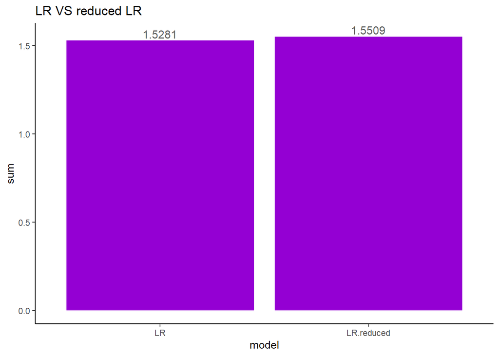

```r
lr.plots = both.df[1,c(1,4)]
lr.plots[2,1] = c("LR.reduced")
lr.plots[2,2] = conf.lr2$overall[1]+conf.lr2$byClass[1]

lr.plots.plot = ggplot(aes(x=method, y=sum), data = lr.plots) + geom_col(fill = "darkviolet") + ylab("sum") + xlab("model") + ggtitle("LR VS reduced LR") + geom_text(aes(label = round(sum,4)), colour = "grey38", size = 4, vjust = -0.3) + theme_classic()
lr.plots.plot
```

# Test the model on test set

```r
# LR on test set:
pred.test.lr = predict(logit.reg, test.lr[,-10], type = "response")
conf.test.lr = confusionMatrix(as.factor(ifelse(pred.test.lr > cut_off.best, 1, 0)), test.lr$stroke, positive = "1")
conf.test.lr
```

```
## Confusion Matrix and Statistics
##
##           Reference
## Prediction   0   1
##          0 767  14
##          1 212  29
##
##                Accuracy : 0.7789
##                  95% CI : (0.7521, 0.804)
##     No Information Rate : 0.9579
##     P-Value [Acc > NIR] : 1
##
##                   Kappa : 0.143
##
##  Mcnemar's Test P-Value : <0.0000000000000002
##
##             Sensitivity : 0.67442
##             Specificity : 0.78345
##          Pos Pred Value : 0.12033
##          Neg Pred Value : 0.98207
##              Prevalence : 0.04207
##          Detection Rate : 0.02838
##    Detection Prevalence : 0.23581
##       Balanced Accuracy : 0.72894
##
##        'Positive' Class : 1
##
```

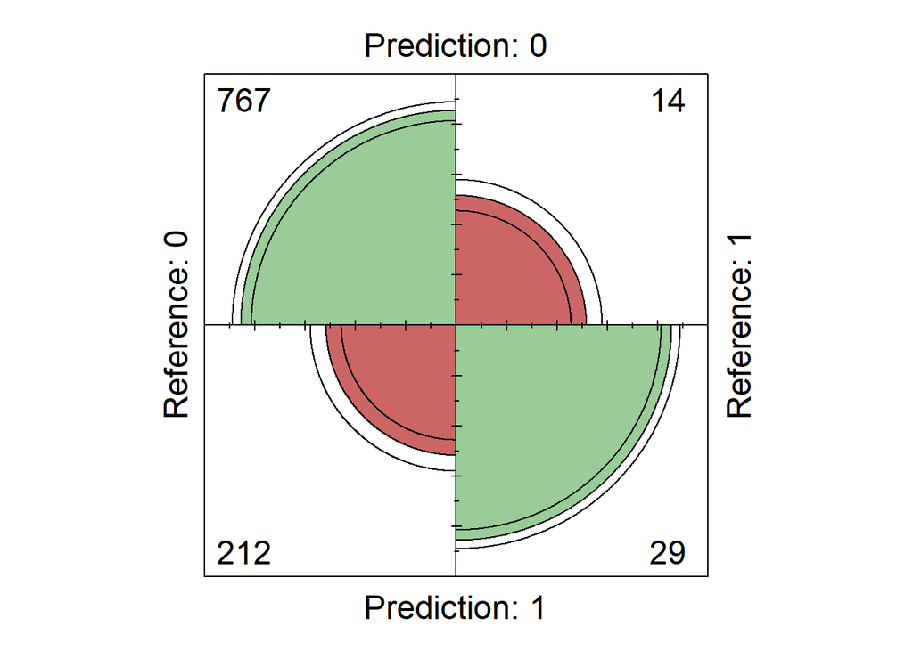

```r
fourfoldplot(confusionMatrix(as.factor(ifelse(pred.test.lr > cut_off.best, 1, 0)), test.lr$stroke, positive = "1")$table, color = c("#CC6666", "#99CC99"))
```

```r
# Reduced LR on test set:
pred.test.lr2 = predict(logit.reg2, test.lr[,-10], type = "response")
conf.test.lr2 = confusionMatrix(as.factor(ifelse(pred.test.lr2 > cut_off.best, 1, 0)), test.lr$stroke, positive = "1")
conf.test.lr2
```

```
## Confusion Matrix and Statistics
##
##           Reference
## Prediction   0   1
##          0 770  13
##          1 209  30
##
##                Accuracy : 0.7828
##                  95% CI : (0.7562, 0.8077)
##     No Information Rate : 0.9579
##     P-Value [Acc > NIR] : 1
##
##                   Kappa : 0.1523
##
##  Mcnemar's Test P-Value : <0.0000000000000002
##
##             Sensitivity : 0.69767
##             Specificity : 0.78652
##          Pos Pred Value : 0.12552
##          Neg Pred Value : 0.98340
##              Prevalence : 0.04207
##          Detection Rate : 0.02935
##    Detection Prevalence : 0.23386
##       Balanced Accuracy : 0.74210
##
##        'Positive' Class : 1
##
```

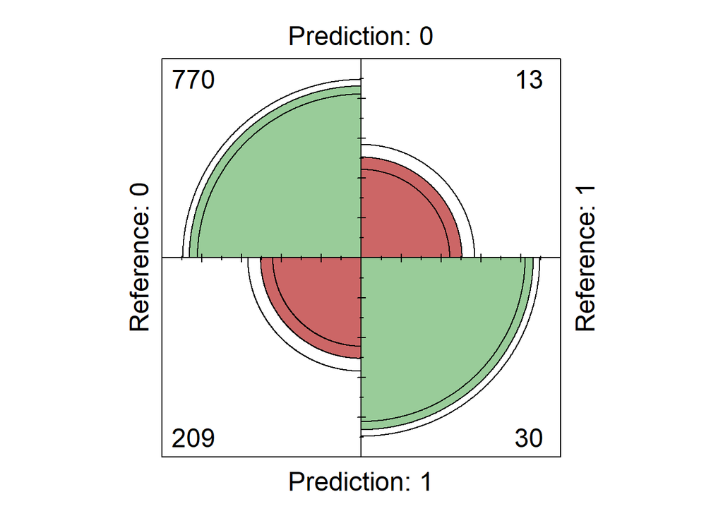

```r
fourfoldplot(confusionMatrix(as.factor(ifelse(pred.test.lr2 > cut_off.best, 1, 0)), test.lr$stroke, positive = "1")$table, color = c("#CC6666", "#99CC99"))
```

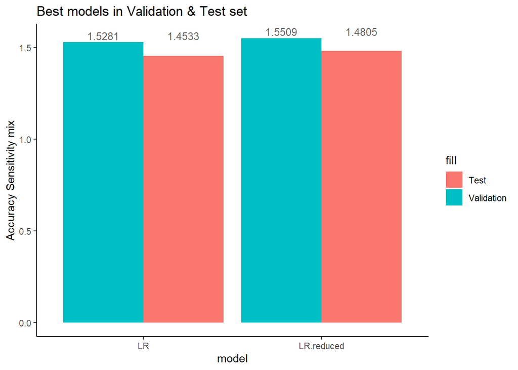

```r
lr.plots[1,3] = conf.test.lr$overall[1]+conf.test.lr$byClass[1]
lr.plots[2,3] = conf.test.lr2$overall[1]+conf.test.lr2$byClass[1]
colnames(lr.plots) <- c("method", "valid", "test")


lr.test.plots = ggplot(lr.plots, aes(x = method, y= valid)) + geom_col(aes(fill = "Validation"), width = 0.45, position = position_nudge(x = -0.225)) + geom_text(aes(label = round(valid,4)), colour = "grey38", size = 3.5, vjust = -0.3, position = position_nudge(x = -0.225))+
  geom_col(aes(y = test, fill = "Test"), width = 0.45, position = position_nudge(x = 0.225)) + geom_text(aes(label = round(test,4)), colour = "grey38", size = 3.5, vjust = -0.3, position = position_nudge(x = 0.225))+
  ylab("Accuracy Sensitivity mix") + xlab("model") + ggtitle("Best models in Validation & Test set") + theme_classic()


lr.test.plots
```

# Gain & decile for best model

We want to know the performance of the best reduced LR model

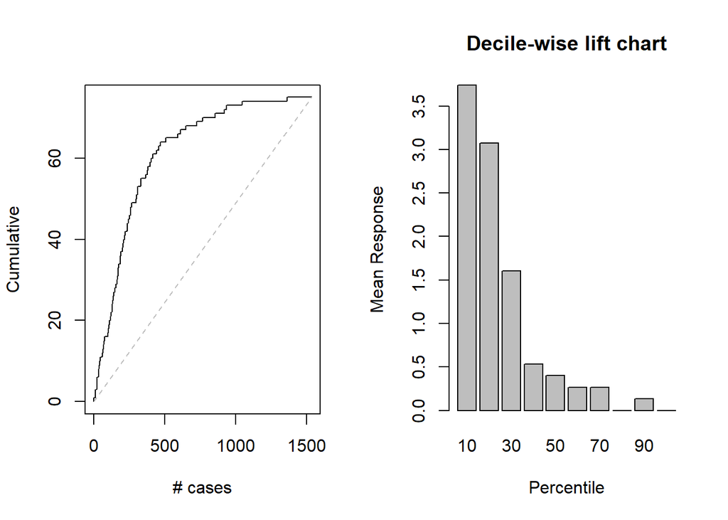

```r
outcome = data.frame(actual = valid.lr$stroke, prob = pred.lr2)

lift <- lift(actual ~ prob, data = outcome)

gain <- gains(predicted = outcome$prob, actual = as.numeric(as.character(outcome$actual)), groups=dim(outcome)[1])

gain.decile <- gains(predicted = outcome$prob, actual = as.numeric(as.character(outcome$actual)))

par(mfrow=c(1,2))

plot(c(0, gain$cume.pct.of.total*sum(as.numeric(as.character(outcome$actual)))) ~ c(0, gain$cume.obs),
xlab = "# cases", ylab = "Cumulative", type="l")
lines(c(0,sum(as.numeric(as.character(outcome$actual))))~c(0,dim(outcome)[1]), col="gray", lty=2)

barplot(gain.decile$mean.resp / mean(as.numeric(as.character(outcome$actual))), names.arg = gain.decile$depth, xlab = "Percentile", ylab = "Mean Response", main = "Decile-wise lift chart")
```

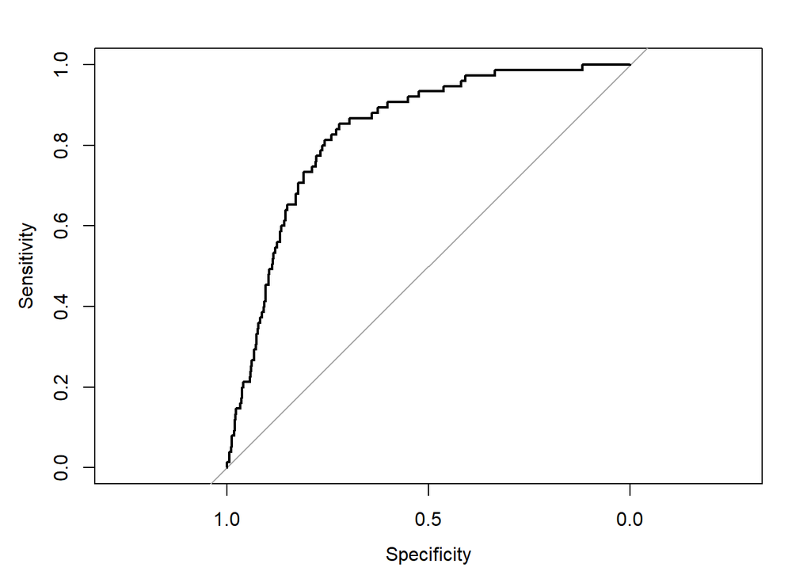

```r
# ROC curve
ROC <- roc(outcome$actual, outcome$prob)
plot.roc(ROC)
```

```r
# Compute AUC
auc(ROC)
```

```
## Area under the curve: 0.8336
```

#### 6) LDA - Linear Discriminant Analysis

The significant predictors are in order (from most influencer to least) age, hypertension, heart_disease, and avg_glucose_level.

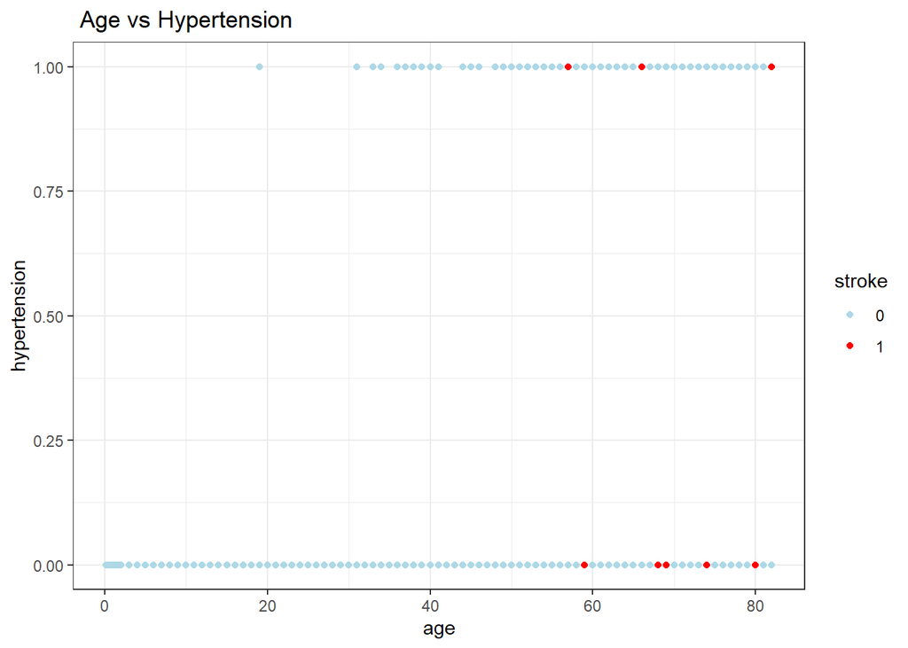

```r
# Draw a colored scatterplot of age and avg_glucose_level:
plot.LDA <- ggplot(data=valid.lr, aes(x=age, y=hypertension)) +
    geom_point(aes(color=stroke)) + labs(title = " Age vs Hypertension") + scale_color_manual(values = c("lightblue", "red")) + theme_bw()
plot.LDA
```

```r
set.seed(1)
# 1) Compute the LDA model using lda() function
lda <- lda(formula = stroke ~ age + hypertension, data = valid.lr)
lda
```

```
## Call:
## lda(stroke ~ age + hypertension, data = valid.lr)
##
## Prior probabilities of groups:
##          0          1
## 0.95107632 0.04892368
##
## Group means:
##        age hypertension
## 0 41.88702   0.08367627
## 1 67.50667   0.21333333
##
## Coefficients of linear discriminants:
##                     LD1
## age          0.04368914
## hypertension 0.49233089
```

```r
set.seed(1)
# 2) Compute LDA with linDA() function:
linDA <- linDA(valid.lr[,c(2,3)], valid.lr[,10], prior= c(ratio_0, ratio_1))
linDA
```

```
##
## Linear Discriminant Analysis
## -------------------------------------------
## $functions        discrimination functions
## $confusion        confusion matrix
## $scores           discriminant scores
## $classification   assigned class
## $error_rate       error rate
## -------------------------------------------
##
## $functions
##               0        1
## constant      -1.9071  -7.7924
## age            0.0901   0.1418
## hypertension  -0.7375  -0.1550
##
##
## $confusion
##         predicted
## original     0     1
##        0  1458     0
##        1    75     0
##
##
## $error_rate
## [1] 0.04892368
##
##
## $scores
##               0           1
## 4119  1.7889121  -1.9771291
## 1380  1.6086201  -2.2608013
## 1050  0.8874523  -3.3954902
## 1708  0.1662844  -4.5301790
## 1087  2.6903719  -0.5587681
## 2566  2.9608099  -0.1332598
## ...
##
## $classification
## [1] 0 0 0 0 0 0
## Levels: 0 1
## ...
```

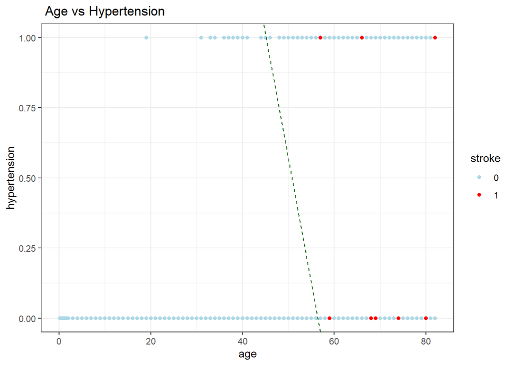

```r
# Estimate DA line (book page 300)
# 1) we must calculate the difference between each classification function coefficients
a_age = linDA$functions[2,2] - linDA$functions[2,1]
a_avg_glucose = linDA$functions[3,2] - linDA$functions[3,1]
# 2) compute the value of intercept and slope
intercept.DA = a_age/a_avg_glucose * (lda$means[1,1] + lda$means[2,1])/2 + (lda$means[1,2] + lda$means[2,2])/2
  #(mean(system_admin$Experience) + mean(system_admin$Training))
slope.DA = - a_age/a_avg_glucose

plot.LDA <- plot.LDA + geom_abline(intercept = intercept.DA, slope = slope.DA, color = "dark green", linetype = "dashed")
plot.LDA
```

Since the cost of misclassifying a stroke is different from the cost of misclassifying a non-stroke, we want to minimize the expected cost of misclassification rather than the simple error rate (which does not account for unequal misclassification costs).

- q(0) the cost of misclassifying a class 0 member (into class 1);
- q(1) the cost of misclassifying a class 1 member (into class 0);

The cost must be integrated into the constants of the classification functions by adding log(q1) to the constant for class 1 (book, page 303). Thus, the score for class 1 membership would increase: observations become more easily classified as stroke (= belonging to class 1) with the modified (increased) constant coefficients, in order to avoid the cost of a mistake (= misclassifying stroke as non-stroke).

To determine the relationship cost requires domain knowledge: is classifying a non-stroke as stroke 20, 30, 40 times higher, than not detecting it? In medical field, it is the false negatives that are dangerous.